# Pendugaan Parameter, Diagnostik Model, dan Peramalan

### Uji Formal

```r
#1) Sisaan Menyebar Normal
tseries::jarque.bera.test(sisaan.da)  #tak tolak H0 > sisaan menyebar normal
```

```
##
##  Jarque Bera Test
##
## data:  sisaan.da
## X-squared = 0.69234, df = 2, p-value = 0.7074
```

Selain dengan eksplorasi, asumsi tersebut dapat diuji menggunakan uji formal. Pada tahapan ini uji formal yang digunakan untuk normalitas adalah uji Jarque Bera . Hipotesis pada uji Jarque Bera adalah sebagai berikut.

$H_0$ : Sisaan menyebar normal

$H_1$ : Sisaan tidak menyebar normal

```r
#2) Sisaan saling bebas/tidak ada autokorelasi
Box.test(sisaan.da, type = "Ljung")  #tak tolak H0 > sisaan saling bebas
```

```
##
##  Box-Ljung test
##
## data:  sisaan.da
## X-squared = 2.1805, df = 1, p-value = 0.1398
```

Selanjutnya akan dilakukan uji formal untuk kebebasan sisaan menggunakan uji Ljung-Box. Hipotesis yang digunakan adalah sebagai berikut.

$H_0$ : Sisaan saling bebas

$H_1$ : Sisaan tidak tidak saling bebas

Berdasarkan uji Ljung-Box tersebut, didapat *p-value* sebesar 0.1398 yang lebih besar dari taraf nyata 5% sehingga tak tolak $H_0$ dan menandakan bahwa sisaan saling bebas. Hal ini sesuai dengan hasil eksplorasi.

```r
#3) Sisaan homogen
Box.test((sisaan.da)^2, type = "Ljung")  #tak tolak H0 > sisaan homogen
```

```
##
##  Box-Ljung test
##
## data:  (sisaan.da)^2
## X-squared = 0.89689, df = 1, p-value = 0.3436
```

Hipotesis yang digunakan untuk uji kehomogenan ragam adalah sebagai berikut.

$H_0$ : Ragam sisaan homogen

$H_1$ : Ragam sisaan tidak homogen

Berdasarkan uji Ljung-Box terhadap sisaan kuadrat tersebut, didapat *p-value* sebesar 0.3436 yang lebih dari taraf nyata 5% sehingga tak tolak $H_0$ dan menandakan bahwa ragam sisaan homogen.

```r
#4) Nilai tengah sisaan sama dengan nol
t.test(sisaan.da, mu = 0, conf.level = 0.95)  #tak tolak h0 > nilai tengah sisaan sama dengan 0
```

```
##
##  One Sample t-test
##
## data:  sisaan.da
## t = -0.33337, df = 118, p-value = 0.7394
## alternative hypothesis: true mean is not equal to 0
## 95 percent confidence interval:
##  -1.427332  1.016003
## sample estimates:
##  mean of x
## -0.2056647
```

Terakhir, dengan uji-t, akan dicek apakah nilai tengah sisaan sama dengan nol. Hipotesis yang diujikan sebagai berikut.

$H_0$ : nilai tengah sisaan sama dengan 0

$H_1$ : nilai tengah sisaan tidak sama dengan 0

Berdasarkan uji-ttersebut, didapat *p-value* sebesar 0.7394 yang lebih besar dari taraf nyata 5% sehingga tak tolak $H_0$ dan menandakan bahwa nilai tengah sisaan sama dengan nol. Hal ini sama dengan hasil eksplorasi.

## Overfitting

Tahapan selanjutnya adalah *overfitting* dilakukan dengan menaikkan orde AR(p) dan MA(q) dari model ARIMA(0,1,2) untuk melihat apakah terdapat model lain yang lebih baik dari model saat ini. Kandidat model *overfitting* adalah ARIMA(1,1,2) dan ARIMA(0,1,3).

### Model ARIMA(1,1,2)

```r
model.overfit1=Arima(train.diff, order=c(1,1,2),method="ML")
summary(model.overfit1) #798.02
```

```
## Series: train.diff
## ARIMA(1,1,2)
##
## Coefficients:
##           ar1      ma1     ma2
##       -0.2213  -1.6456  0.6456
## s.e.   0.1226   0.1100  0.1077
##
## sigma^2 = 45.36:  log likelihood = -395.01
## AIC=798.02   AICc=798.37   BIC=809.1
##
## Training set error measures:
##                       ME     RMSE      MAE MPE MAPE      MASE       ACF1
## Training set -0.09217524 6.620467 5.269615 NaN  Inf 0.4072132 0.00484327
```

```r
lmtest::coeftest(model.overfit1) #ar1 tidak signifikan
```

```
##
## z test of coefficients:
##
##     Estimate Std. Error  z value  Pr(>|z|)
## ar1 -0.22134    0.12265  -1.8047   0.07113 .
## ma1 -1.64562    0.11001 -14.9585 < 2.2e-16 ***
## ma2  0.64562    0.10770   5.9948 2.037e-09 ***
## ---
## Signif. codes:  0 '***' 0.001 '**' 0.01 '*' 0.05 '.' 0.1 ' ' 1
```

### Model ARIMA(0,1,3)

```r
model.overfit2=Arima(train.diff, order=c(0,1,3),method="ML")
summary(model.overfit2) #798.74
```

```
## Series: train.diff
## ARIMA(0,1,3)
##
## Coefficients:
##           ma1     ma2      ma3
##       -1.8454  0.9753  -0.1299
## s.e.   0.0922  0.1549   0.0808
##
## sigma^2 = 45.62:  log likelihood = -395.37
## AIC=798.74   AICc=799.1   BIC=809.83
##
## Training set error measures:
##                      ME     RMSE      MAE MPE MAPE      MASE        ACF1
## Training set -0.1070217 6.639746 5.310216 NaN  Inf 0.4103507 -0.02325722
```

```r
lmtest::coeftest(model.overfit2) #ma3 tidak signifikan
```

```
##
## z test of coefficients:
##
##      Estimate Std. Error  z value  Pr(>|z|)
## ma1 -1.845431   0.092214 -20.0125 < 2.2e-16 ***
## ma2  0.975311   0.154948   6.2944 3.085e-10 ***
## ma3 -0.129878   0.080831  -1.6068    0.1081
## ---
## Signif. codes:  0 '***' 0.001 '**' 0.01 '*' 0.05 '.' 0.1 ' ' 1
```

```r
#model yang dipilih adalah model awal, yaitu ARIMA(0,1,2)
```

## Peramalan

Peramalan dilakukan menggunakan fungsi `forecast()` . Contoh peramalan berikut ini dilakukan untuk 30 periode ke depan.

```r
#---FORECAST---#
ramalan.da <- forecast::forecast(model4.da, h = 30)
ramalan.da
```

```
##     Point Forecast      Lo 80     Hi 80     Lo 95    Hi 95
## 121    0.450222594  -8.290773  9.191218 -12.91798 13.81842
## 122   -0.005521503 -10.897576 10.886533 -16.66348 16.65244
## 123   -0.005521503 -10.897576 10.886533 -16.66348 16.65244
## 124   -0.005521503 -10.897576 10.886533 -16.66348 16.65244
## 125   -0.005521503 -10.897576 10.886533 -16.66348 16.65244
## 126   -0.005521503 -10.897576 10.886533 -16.66348 16.65244
## 127   -0.005521503 -10.897576 10.886533 -16.66348 16.65244
## 128   -0.005521503 -10.897576 10.886533 -16.66348 16.65244
## 129   -0.005521503 -10.897576 10.886533 -16.66348 16.65244
## 130   -0.005521503 -10.897576 10.886533 -16.66348 16.65244
## 131   -0.005521503 -10.897576 10.886533 -16.66348 16.65244
## 132   -0.005521503 -10.897576 10.886533 -16.66348 16.65244
## 133   -0.005521503 -10.897576 10.886533 -16.66348 16.65244
## 134   -0.005521503 -10.897576 10.886533 -16.66348 16.65244
```

[output cut: 16 more lines]

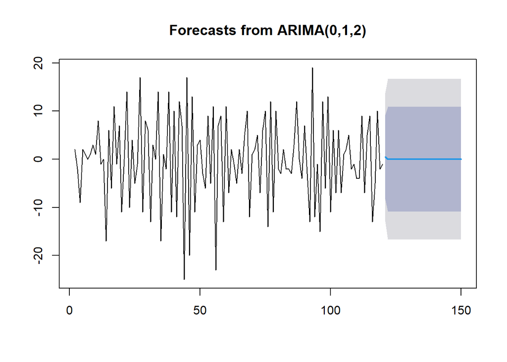

```r
data.ramalan.da <- ramalan.da$mean
plot(ramalan.da)
```

Berdasarkan hasil plot ramalan di atas, dapat dilihat bahwa ramalan ARIMA(0,1,2) cenderung stabil hingga akhir periode. Selanjutnya, dapat dicari nilai akurasi antara hasil ramalan dengan data uji sebagai berikut.

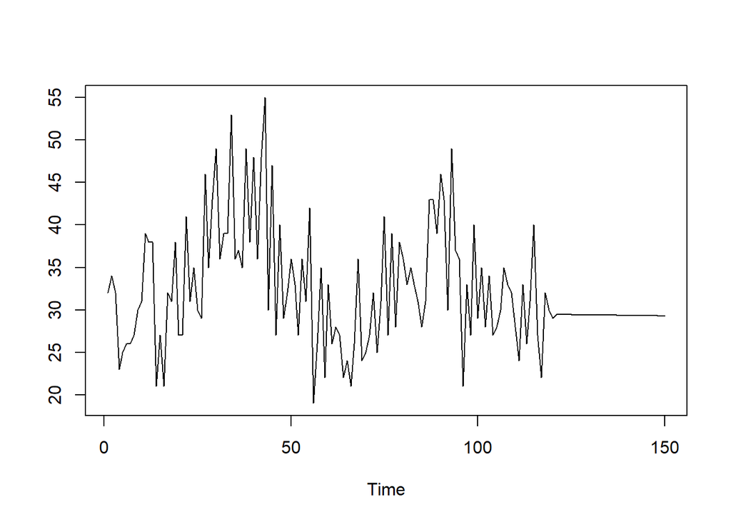

```r
pt_1 <- train.ts[120] #nilai akhir data latih
hasil.forc.Diff <- data.ramalan.da
hasil <- diffinv(hasil.forc.Diff, differences = 1) + pt_1

#has.1 sama hasilnta dengan: cumsum(c(pt_1,hasil.forc.Diff))
ts.plot(train.ts,hasil)
```

```r
perbandingan.da<-matrix(data=c(head(test.ts, n=30), hasil[-1]),
                     nrow = 30, ncol = 2)
colnames(perbandingan.da)<-c("Aktual","Hasil Forecast")
perbandingan.da
```

```
##       Aktual Hasil Forecast
##  [1,]     28       29.45022
##  [2,]     38       29.44470
##  [3,]     42       29.43918
##  [4,]     30       29.43366
##  [5,]     31       29.42814
##  [6,]     28       29.42262
##  [7,]     37       29.41709
##  [8,]     39       29.41157
##  [9,]     40       29.40605
## [10,]     34       29.40053
## [11,]     46       29.39501
## [12,]     43       29.38949
## [13,]     30       29.38396
## [14,]     26       29.37844
```

[output cut: 16 more lines]

```r
accuracy(ts(hasil[-1]), head(test.ts, n=30))
```

```
##                ME     RMSE      MAE      MPE     MAPE       ACF1 Theil's U
## Test set 7.829839 10.60193 8.466299 18.07318 20.46849 0.09501679  1.118426
```

Didapati bahwa nilai MAPE mencapai 20.47%, yang mengindikasikan bahwa model prediksi rata-rata mengalami deviasi sekitar 21% dari nilai sebenarnya. Saat dilakukan pengecekan stasioneritas, ditemukan bahwa data tidak menunjukkan stasioneritas baik dalam rataan maupun dalam ragam. Namun, dalam analisis ini, hanya masalah ketidakstasioneran dalam rataan yang telah diatasi. Sayangnya, ketidakstasioneran dalam ragam masih menjadi permasalahan yang belum terpecahkan. Hal ini dapat berpotensi menjadi salah satu penyebab mengapa nilai MAPE dari model masih relatif tinggi.